# 514 Lab 1

Sagi vijay Rama Raju

Due Date 02/23

```r
# If you don't already have the tidyverse library installed,
# you will need to type install.packages("tidyverse") into the Console
library(tidyverse)
```

### 1. Changing the author field and file name. (10 points)

##### (a) Change the `author:` field on the Rmd document from Your Name Here to your own name.

##### (b) Rename this file to “HW1_YourHameHere.Rmd”, where YourNameHere is changed to your own name.

### 2. Hello World! (10 points)

Here’s an R code chunk that prints the text ‘Hello world!’.

```r
print("Hello world!")
```

```
## [1] "Hello world!"
```

#### (a) Modify the code chunk below to print your name

```r
print ("Sagi Vijay Rama Raju")
```

```
## [1] "Sagi Vijay Rama Raju"
```

### 3. Creating a numeric vector (30 points)

We just learned about the `c()` operator, which forms a vector from its arguments. If we’re trying to build a vector containing a sequence of numbers, there are several useful functions at our disposal. These are the colon operator `:` and the sequence function `seq()`.

##### `:` Colon operator:

```r
1:10 # Numbers 1 to 10
```

```
##  [1]  1  2  3  4  5  6  7  8  9 10
```

```r
127:132 # Numbers 127 to 132
```

```
## [1] 127 128 129 130 131 132
```

##### `seq` function: `seq(from, to, by)`

```r
seq(1,10,1) # Numbers 1 to 10
```

```
##  [1]  1  2  3  4  5  6  7  8  9 10
```

```r
seq(1,10,2) # Odd numbers from 1 to 10
```

```
## [1] 1 3 5 7 9
```

```r
seq(2,10,2) # Even numbers from 2 to 10
```

```
## [1]  2  4  6  8 10
```

> To learn more about a function, type `?functionname` into your console. E.g., `?seq` pulls up a Help file with the R documentation for the `seq` function.

#### (a) Use `:` to output the sequence of numbers from 3 to 12

```r
3:12
```

```
##  [1]  3  4  5  6  7  8  9 10 11 12
```

#### (b) Use `seq()` to output the sequence of numbers from 3 to 30 in increments of 3

```r
seq(3,30,3)
```

```
##  [1]  3  6  9 12 15 18 21 24 27 30
```

#### (c) Save the sequence from (a) as a variable `x`, and the sequence from (b) as a variable `y`. Output their product `x*y`

```r
x<-3:12
y<-seq(3,30,3)
x*y
```

```
##  [1]   9  24  45  72 105 144 189 240 297 360
```

### 4. Cars data (50 points)

We’ll look at data frame and plotting in much more detail in later classes. For a previous of what’s to come, here’s a very basic example.

For this example we’ll use a very simple dataset. The `cars` data comes with the default installation of R. To see the first few columns of the data, just type `head(cars)`.

```r
head(cars)
```

```
##   speed dist
## 1     4    2
## 2     4   10
## 3     7    4
## 4     7   22
## 5     8   16
## 6     9   10
```

#### (a) Calculate the average and standard deviation of `speed`

```r
chev<- cars$speed
print (mean(chev)) #mean of speed
```

```
## [1] 15.4
```

```r
print(sd(chev)) #standard deviation rooot of S
```

```
## [1] 5.287644
```

#### (b) Calculate the average and standard deviation of `dist`

```r
mar<- cars$dist # creating an object
print (mean(mar)) #mean/average of the distance
```

```
## [1] 42.98
```

```r
print (sd(mar)) #standard deviation of dist
```

```
## [1] 25.76938
```

We can easily produce a histogram of stopping distance using the `qplot` function (built-in `tidyverse` package).

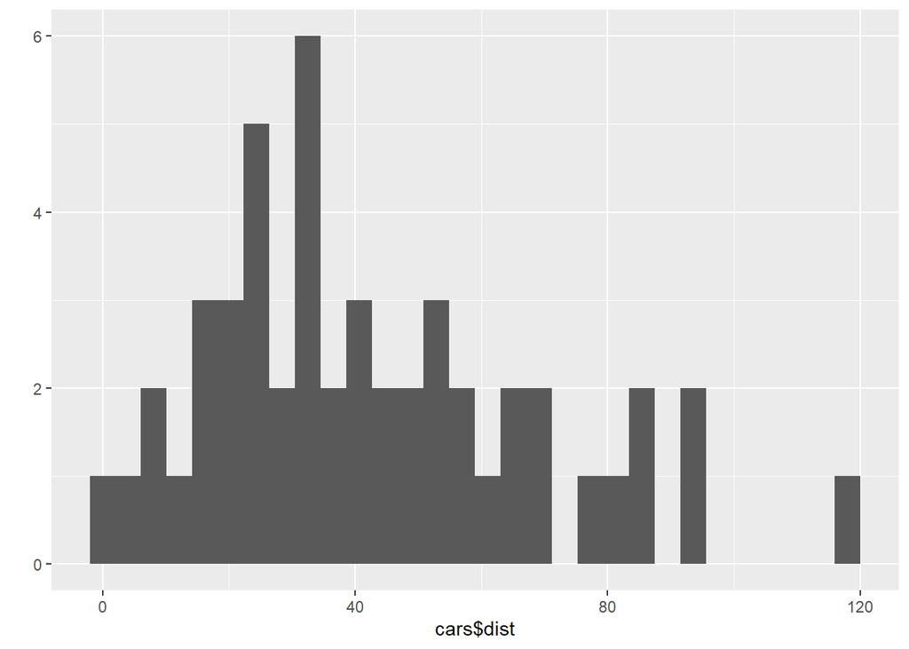

```r
qplot(cars$dist) # Histogram of stopping distance
```

How to change the number of bins?

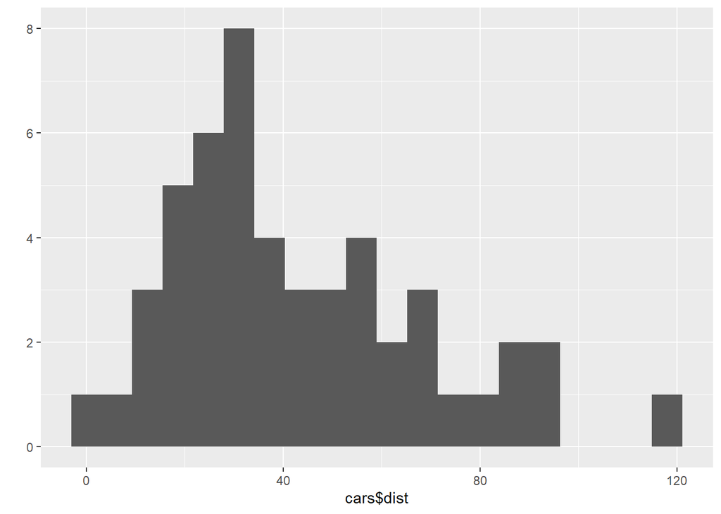

```r
qplot(cars$dist,bins = 20)
```

#### (c) Produce a histogram of speed using the `qplot` function with **5 bins**.

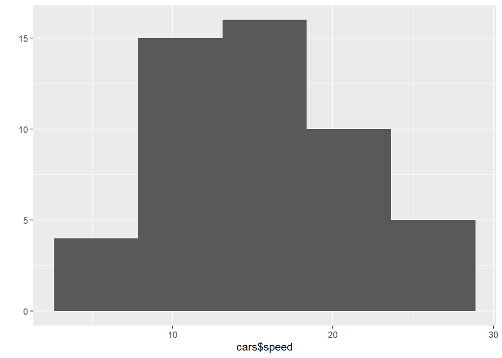

```r
qplot (cars$speed,bins = 5)
```

The `qplot(x,y,...)` function can also be used to plot a vector `y` against a vector `x`. You can type `?qplot` into the Console to learn more about the basic qplot function.

#### (d) Use the `qplot(x,y)` function to create a scatterplot of dist against speed.

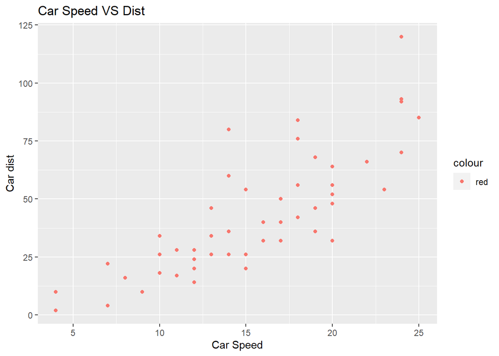

```r
qplot(cars$speed,cars$dist,
      col="red",
      main="Car Speed VS Dist",
      xlab = "Car Speed",
      ylab = "Car dist"
      )
```

#### (e) Use the `boxplot` function to create a boxplot of speed.

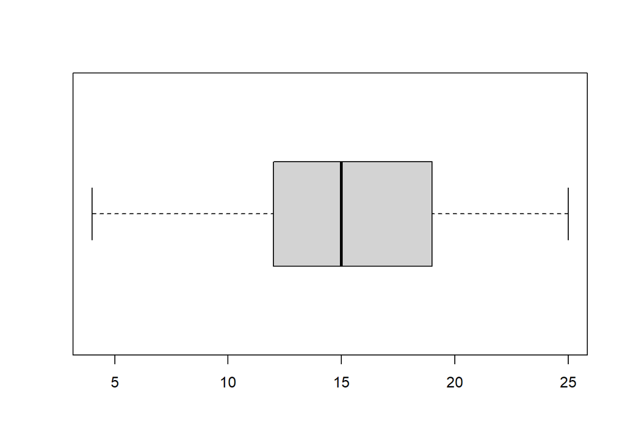

```r
boxplot(cars$speed, horizontal = TRUE)
```